## Analysis of data as described in the manuscript “RNA-Sequencing data for 7706 tumor samples across 20 cancer types from The Cancer Genome Atlas”"

#### Preliminary steps

- Manually download the RNA-Seq data for GFP and HER2 overexpressed human mammary epithelial cells from GEO (accession# GSE62820)
- Manually download the compiled RNA-Seq and clinical data from GEO (accession# GSE62944). The Scripts/process_tcga_rsubread script contains code that shows how we processed the RNA-Seq data. The Codes/ProcessClinicalData.R script in our repository contains the code that we used to generate the clinical file. Please these in the Analysis_datasets directory.
- Install and load the required R packages for analysis: “stats”, “ROCR”, “pROC”. The following code demonstrates how to do this.
- Set the working directory in R to the `TCGA_RNASeq_clinical/Analysis_datasets` directory in this repository.

```r
if (!require("stats")) {
   install.packages("stats", dependencies = TRUE)
   library(stats)
   }
if (!require("ROCR")) {
   install.packages("ROCR", dependencies = TRUE)
   library(stats)
   }
if (!require("pROC")) {
   install.packages("pROC", dependencies = TRUE)
   library(stats)
   }
if (!require("data.table")) {
   install.packages("data.table", dependencies = TRUE)
   library(data.table)
   }
```

The following code reads data files that have been preprocessed using both pipelines.

```r
# TCGA pipeline, expected counts
setwd("~/Dropbox/TCGA_RNASeq_Clinical/Analysis_datasets/")
rsem_her2_expected_counts<-read.table("GFP18_HER2_TCGA_Pipeline_Expected_Gene_Counts.txt", sep='\t', header=1, row.names=1, check.names=F) # This was downloaded from GEO Accession # GSE62820 and unzipped

# Rsubread pipeline, gene counts
feature<-read.table("GFP18_HER2_Rsubread_geneCounts.txt", sep='\t',header=1, row.names=1, check.names = F) # This was downloaded from GEO Accession # GSE62820 and unzipped

# TCGA pipeline, normalized expression files
TCGA_her2<-read.table("GFP18_HER2_TCGA_Pipeline_Normalized_Genes_Results.txt", sep='\t', header=1, check.names=F) # This was downloaded from GEO Accession # GSE62820 and unzipped

# Rsubread pipeline, FPKM values
rsub_fpkm<-read.table("GFP18_HER2_Rsubread_FPKM.txt", sep='\t',header=1, row.names=1, check.names = F) # This was downloaded from GEO Accession # GSE62820 and unzipped
rsub_fpkmlog<-log2(rsub_fpkm+1)

# Rsubread pipeline, TPM values
rsub_tpm<-read.table("GFP18_HER2_Rsubread_TPM.txt", sep='\t',header=1, row.names=1, check.names = F) # This was downloaded from GEO Accession # GSE62820 and unzipped
rsub_tpmlog<-log2(rsub_tpm+1)

# Clinical data
clinicals<-t(read.delim('TCGA20_clinical_data_ordered_all_clinical_variables_samples_as_columns.txt',sep='\t',header=1, row.names=1,check.names=F)) # This was downloaded from GEO Accession # GSE62820 and unzipped
```

We used BinReg 2 to make HER pathway predictions. The following code reads the resulting prediction files into R.

```r
setwd("~/Dropbox/TCGA_RNASeq_Clinical/Analysis_datasets/")
rsub_preds<-read.table("rsubread_10_14.txt", sep='\t', header=1, row.names=1)
tcga_preds<-read.table("Rsem_10_14.txt", sep='\t', header=1, row.names=1)
```

We calculate the number of zero values per sample across the TCGA data set. The Codes/numZero.R script was used to generate the files containing the total number of zero expressing genes per samples.

```r
setwd("~/Dropbox/TCGA_RNASeq_Clinical/Analysis_datasets/")
pancan12_zero<-read.table("PANCAN12_19583_by_3380_numZeroes.txt",row.names=1,sep='\t')# File is at Analysis_datasets
pancan20_tpm_zero<-read.table("PANCAN20_19583_by_3380_numZeroes.txt",sep='\t',row.names=1)# File is at Analysis_datasets
```

We used Random Forests regression to predict lung-cancer type based on RNA-Seq data. The R script for generating the predictions for this analysis is located at Code/Classify_luad_vs_lusc.R. LUAD and LUSC TCGA Level 3 data was downloaded from TCGA data portal and Rsubread TPM normalized LUAD and LUSC data was used in this analysis.

```r
setwd("~/Dropbox/TCGA_RNASeq_Clinical/Analysis_datasets/")
data12 = read.table("Classification_12_LUAD_LUSC_Predictions.txt", sep="\t", stringsAsFactors=FALSE, header=TRUE, row.names=1) # File is at Analysis_datasets
data20 = read.table("Classification_20_LUAD_LUSC_Predictions.txt", sep="\t", stringsAsFactors=FALSE, header=TRUE, row.names=1)# File is at Analysis_datasets
```

## Helper functions

```r
#This function calculates the standardized mean using Hedge's formula
standardized_mean<-function(m.1,sd.1,n.1,m.2,sd.2,n.2){
  sd_pooled=sqrt(((n.1-1)*sd.1^2+(n.2-1)*sd.2^2)/(n.1+n.2-2))
  (m.1-m.2)/sd_pooled
  }

#This function merges two matrices on row names, sets the common items as rownames  and removes the extra column resulting from merge function.
merge_drop<-function(x,y,by=0)
{
  new_m<-merge(x,y,by=by)
  rownames(new_m)<-new_m$Row.names
  return(new_m[,2:length(colnames(new_m))])
}

#This function plots the ROC based on the actual and predicted class
plotROC = function(actual, probabilities, plotCI=FALSE)
{
  # bottom, left, top, right
  par(mar=c(4.5, 4.7, 0.0, 0.5),lwd=4)

  library(pROC)
  roc_result = roc(actual ~ probabilities, ci=TRUE, plot=TRUE, print.auc=FALSE,lwd=4)
  lowerBoundAuc = format(roc_result$ci[1], digits=3)
  midAuc = format(roc_result$ci[2], digits=3)
  upperBoundAuc = format(roc_result$ci[3], digits=3)

  if (plotCI)
  {
    ci(roc_result)
    sens.ci <- ci.se(roc_result)
    plot(sens.ci, type="shape", col="lightgrey",lwd=1)
    plot(sens.ci, type="bars",col="lightgrey",lwd=1)
    plot(roc_result, add=TRUE)
  }

  #text(0.5, 0.00, labels=paste("AUC: ", midAuc, " (", lowerBoundAuc, "-", upperBoundAuc, ")", sep=""))

  par(mar=c(5.1, 4.1, 2.1, 2.1))
}
```

### ‘Gene count’ level analysis

We compared gene counts results using GFP control protein and ERBB2 protein overexpressed human mammary epithelial cell samples. TCGA’s pipeline and Rsubread pipelines were used to generate raw gene level counts. Log based 2 gene counts are used to differentiate between control and ERBB2 overexpressed samples.

First, we computed the empiric cumulative distribution for all samples from the two pipelines. Second, we compared the total mapped reads per HMEC samples for the TCGA pipeline and Rsubread pipeline. Raw gene counts for GFP and HER2 HMEC samples were processed via the TCGA pipeline (expected counts) and the Rsubread pipeline (integer based), This analysis was done before any normalization method was applied.

```r
##########computing the empiric cumulative distribution per sample overlaied on same graph########
###using TCGA pipelined aligned data
ecdf_all_ex<-apply(log2(rsem_her2_expected_counts+1),2,ecdf)
par( mfrow = c( 1, 2 ) )
plot(ecdf_all_ex[[1]],xlab="log2(Total mapped reads)",ylab="Cumulative proportion",col="blue",main="TCGA pipeline",ylim=c(0,1),xlim = c(0,20),cex.axis=1.5, cex.lab=1.5)
legend(10,10,c("GFP", "HER2"), col = c("blue","brown"))
for(i in 2:12){lines(ecdf_all_ex[[i]],xlab=NA, ylab = NA,col="blue")}
for(i in 13:17){lines(ecdf_all_ex[[i]],xlab=NA, ylab = NA,col="brown")}
###if outlier samples were removed
rsem_her2_expected_counts_f<-rsem_her2_expected_counts[,c(1:11,13,15,17)]
head(rsem_her2_expected_counts_f)
```

```
##           GFP-1 GFP-2 GFP-3 GFP-4 GFP-5 GFP-6 GFP-7 GFP-8 GFP-9 GFP-10
## UBE2Q1     1282  1245   923  1218  1554   968  1379  1073  1348   1175
## RNF14       959   841   676   826  1061   705   882   813   849    705
## SERPINB11     0     0     0     0     1     0     0     0     0      0
## RNF17         0     0     0     0     0     0     0     0     0      0
## RNF10      1593  1420  1132  1572  2124  1310  1529  1246  1532   1348
## RNF11      1432  1065   909  1243  1971  1178  1040   991  1048    954
##           GFP-11 HER2-1 HER2-3 HER2-6
## UBE2Q1      1175   1368   1512   1060
## RNF14        705   1098   1096    831
## SERPINB11      0      0      0      0
## RNF17          0      0      0      0
## RNF10       1348   1530   1800   1255
## RNF11        954   1349   1531   1070
```

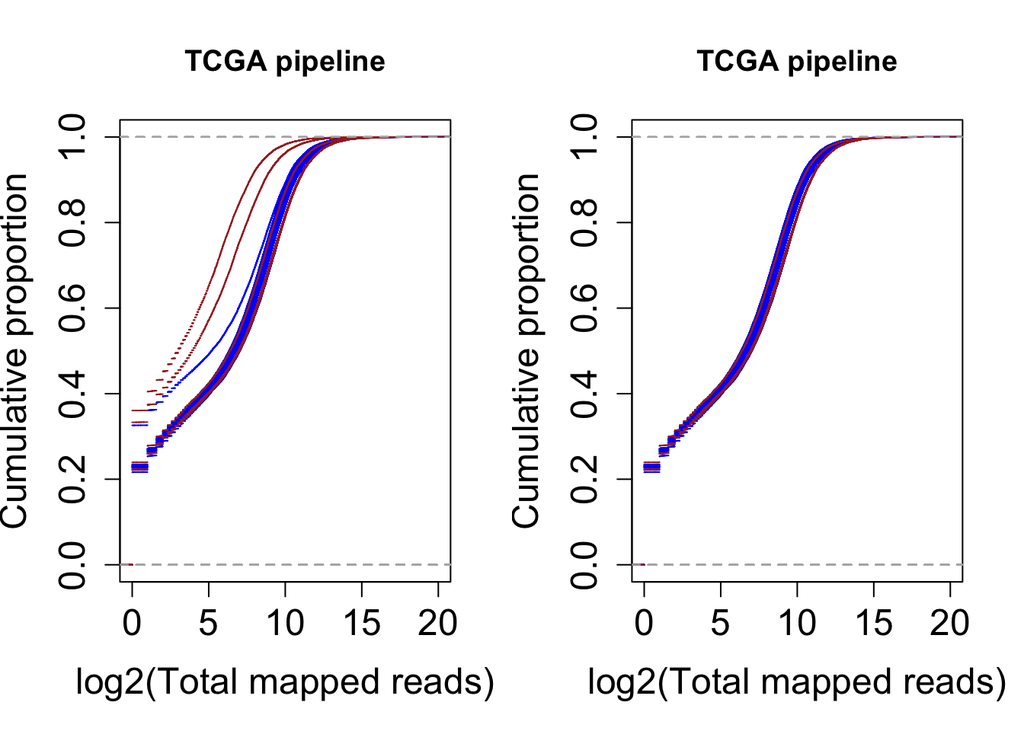

```r
ecdf_all_ex_f<-apply(log2(rsem_her2_expected_counts_f+1),2,ecdf)

plot(ecdf_all_ex_f[[1]],xlab="log2(Total mapped reads)",ylab="Cumulative proportion",col="blue",main="TCGA pipeline",ylim=c(0,1),xlim = c(0,20),cex.axis=1.5, cex.lab=1.5)
legend(10,10,c("GFP", "HER2"), col = c("blue","brown"))
for(i in 2:11){lines(ecdf_all_ex_f[[i]],xlab=NA, ylab = NA,col="blue")}
for(i in 12:14){lines(ecdf_all_ex_f[[i]],xlab=NA, ylab = NA,col="brown")}
```

```r
###using Rsubread pipeline aligned data
ecdf_all<-apply(log2(feature+1),2,ecdf)
plot(ecdf_all[[1]],xlab="log2(Total mapped reads)",ylab="Cumulative proportion",col="blue",main="Rsubread pipeline",ylim=c(0,1),xlim = c(0,20),cex.axis=1.5, cex.lab=1.5)
for(i in 2:12){lines(ecdf_all[[i]],xlab=NA,ylab = NA,col="blue")}
for(i in 13:17){lines(ecdf_all[[i]],xlab=NA,ylab = NA,col="brown")}

###if outlier samples were removed
feature_f<-feature[,c(1:11,13,15,17)]
head(feature_f)
```

```
##              GFP-1 GFP-2 GFP-3 GFP-4 GFP-5 GFP-6 GFP-7 GFP-8 GFP-9 GFP-10
## MTVR2            0     0     0     0     0     1     0     0     1      0
## CHMP1B        1835  1367  1554  1787  2594  1599  1471  1358  1574   1202
## DISC2            0     0     0     0     0     0     0     0     0      0
## LOC100506866    25    21    24    25    31    17    25    14    28     21
## LOC441204        0     0     1     0     0     0     0     0     2      0
## TCOF1          835   905   732   907  1034   630  1040   940  1152    992
##              GFP-11 HER2-1 HER2-3 HER2-6
## MTVR2             1      0      0      0
## CHMP1B         2627   2011   2066   1403
## DISC2             0      0      0      0
## LOC100506866     30     26     27     18
## LOC441204         2      0      0      0
## TCOF1          1244   1226   1272    844
```

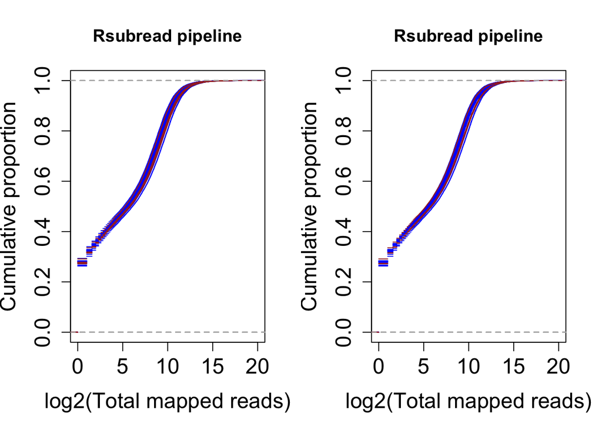

```r
ecdf_f<-apply(log2(feature_f+1),2,ecdf)

plot(ecdf_f[[1]],xlab="log2(Total mapped reads)",ylab="Cumulative proportion",col="blue",main="Rsubread pipeline",ylim=c(0,1),xlim = c(0,20),cex.axis=1.5, cex.lab=1.5)
legend(10,10,c("GFP", "HER2"), col = c("blue","brown"))
for(i in 2:11){lines(ecdf_f[[i]],xlab=NA, ylab = NA,col="blue")}
for(i in 12:14){lines(ecdf_f[[i]],xlab=NA, ylab = NA,col="brown")}
```

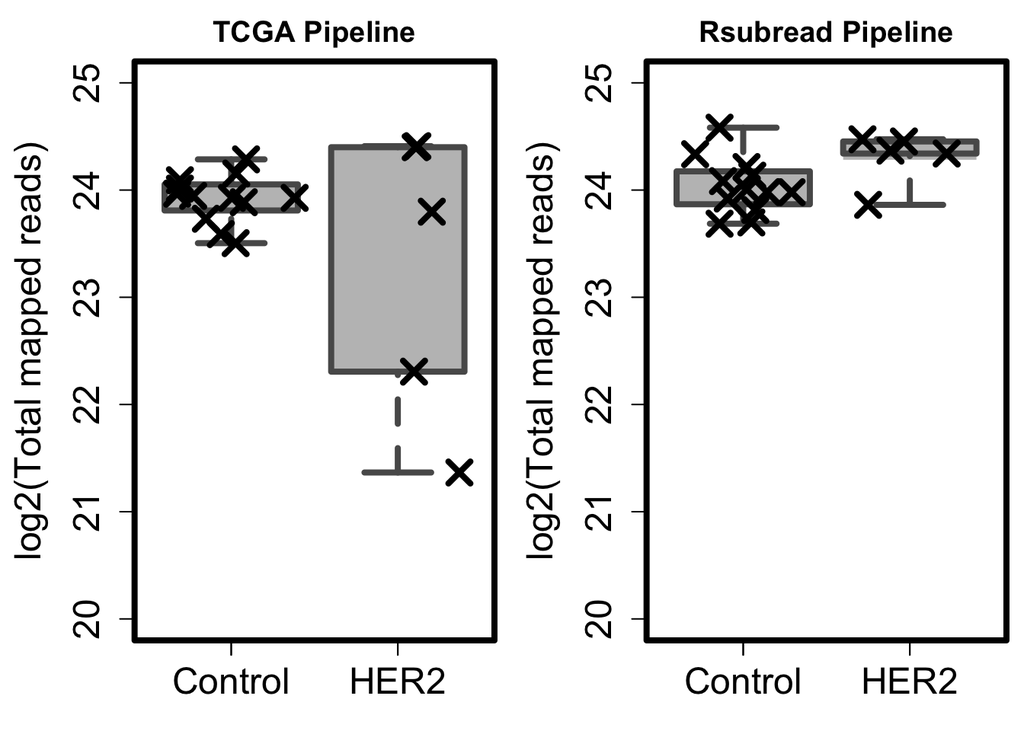

```r
############computing total number of read counts per samples and plotting them as dot plots####
expected_counts<-apply(rsem_her2_expected_counts,2,sum)
feature_counts<-apply(feature,2,sum)
# Creating a plot showing total mapped reads per sample
par( mfrow = c( 1, 2 ),lwd=4 )
x = c(rep(1, 12), rep(2, 5)) # this indicates where on the x axis to plot
par(mar=c(3.1, 4.6, 2.1, 0.6)) # figure margins

boxplot(log2(expected_counts[1:12]+1), log2(expected_counts[13:17]+1),range=0,cex.axis=1.5, cex.lab=1.5,outpch=NA,lwd=4,ylim=c(20,25),xlab="", ylab="log2(Total mapped reads)",main="TCGA Pipeline",col='grey75',medcol="grey75",lwd=4,border = "grey35")

points(jitter(x, factor=2), c(log2(expected_counts[1:12]+1), log2(expected_counts[13:17]+1)), pch=4, cex=2, col=1,  xaxt="n",cex.lab=1.5)
axis(1, at=1:2, tick=T, labels=c("Control", "HER2"), cex.axis=1.5)

boxplot(log2(feature_counts[1:12]+1), log2(feature_counts[13:17]+1),range=0,cex.axis=1.5, cex.lab=1.5,outpch=NA,lwd=4,ylim=c(20,25),xlab="", ylab="log2(Total mapped reads)",col='grey75',medcol="grey75",lwd=4,main="Rsubread Pipeline",border = "grey35")
points(jitter(x, factor=1.5), c(log2(feature_counts[1:12]+1), log2(feature_counts[13:17]+1)), pch=4,cex=2,cex.lab=1.5,col="black")
axis(1, at=1:2, tick=T, labels=c("Control", "HER2"), cex.axis=1.5)
```

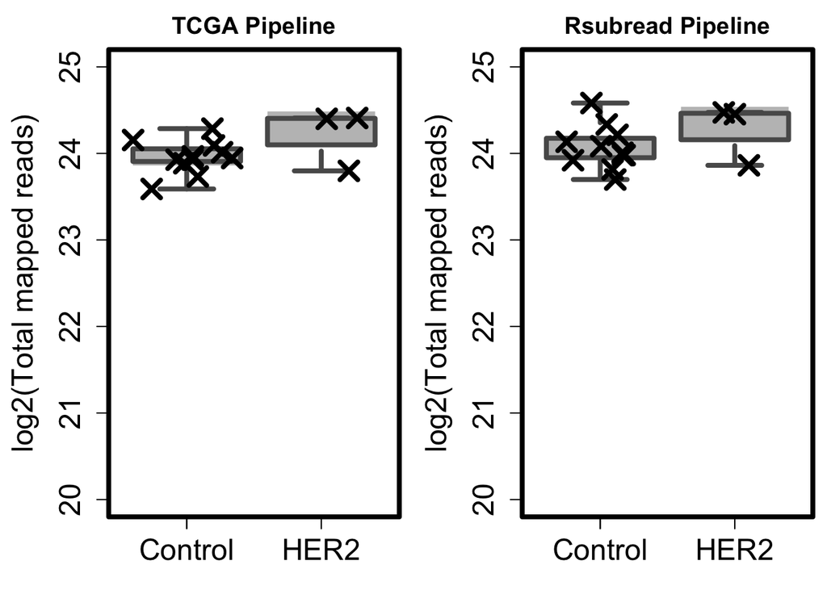

```r
#####
############IF OUTLIER SAMPLES ARE REMOVED####
expected_counts<-apply(rsem_her2_expected_counts_f,2,sum)
feature_counts<-apply(feature_f,2,sum)
# Creating a plot showing total mapped reads per sample
par( mfrow = c( 1, 2 ),lwd=4 )
x = c(rep(1, 11), rep(2, 3)) # this indicates where on the x axis to plot
par(mar=c(3.1, 4.6, 2.1, 0.6)) # figure margins

boxplot(log2(expected_counts[1:11]+1), log2(expected_counts[12:14]+1),range=0,cex.axis=1.5, cex.lab=1.5,outpch=NA,lwd=4,ylim=c(20,25),xlab="", ylab="log2(Total mapped reads)",main="TCGA Pipeline",col='grey75',medcol="grey75",lwd=4,border = "grey35")

points(jitter(x, factor=2), c(log2(expected_counts[1:11]+1), log2(expected_counts[12:14]+1)), pch=4, cex=2, col=1,  xaxt="n",cex.lab=1.5)
axis(1, at=1:2, tick=T, labels=c("Control", "HER2"), cex.axis=1.5)

boxplot(log2(feature_counts[1:11]+1), log2(feature_counts[12:14]+1),range=0,cex.axis=1.5, cex.lab=1.5,outpch=NA,lwd=4,ylim=c(20,25),xlab="", ylab="log2(Total mapped reads)",col='grey75',medcol="grey75",lwd=4,main="Rsubread Pipeline",border = "grey35")
points(jitter(x, factor=1.5), c(log2(feature_counts[1:11]+1), log2(feature_counts[12:14]+1)), pch=4,cex=2,cex.lab=1.5,col="black")
axis(1, at=1:2, tick=T, labels=c("Control", "HER2"), cex.axis=1.5)
```

Third, we are comparing the “ERBB2” gene counts across the experimental treatment to assess how well the two pipelines differentiate control ERRB2 versus overexpressed ERBB2 at the gene counts level.

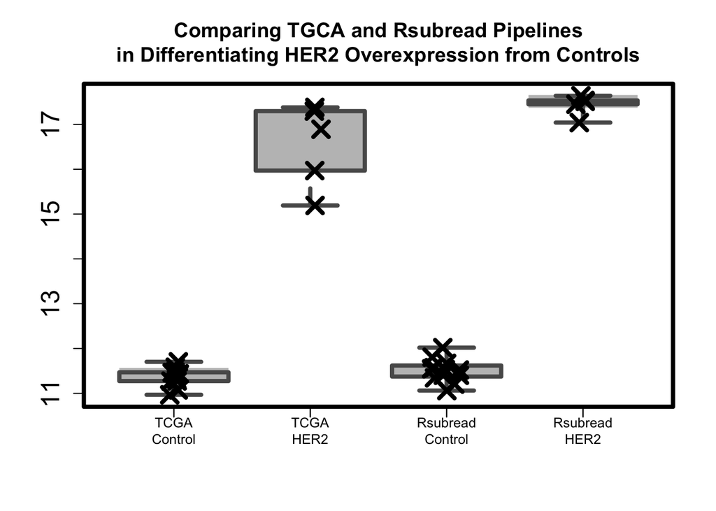

```r
#######Boxplotting ERBB2 gene counts in HMEC samples#####
par(mfrow = c(1, 1),lwd=4)
names=c('TCGA\nGFP','TCGA\nHER2','Rsubread\nGFP', 'Rsubread\nHER2')
rsem_her2<-data.frame(t(rsem_her2_expected_counts["ERBB2",]))
rsub_her2<-data.frame(t(feature["ERBB2",]))
x = c(rep(1, 12), rep(2, 5),rep(3, 12), rep(4, 5))

boxplot(log2(rsem_her2$ERBB2[1:12]+1),log2(rsem_her2$ERBB2[13:17]+1),log2(rsub_her2$ERBB2[1:12]+1),log2(rsub_her2$ERBB2[13:17]+1),ylab="",range=0,cex.axis=1.5, cex.lab=1.5,outpch=NA,col='grey75',medcol="grey75",lwd=4,main=paste('Comparing TGCA and Rsubread Pipelines','\n', 'in Differentiating HER2 Overexpression from Controls',sep=''),border = "grey35")

points(jitter(rep(1,12),factor=2),log2(rsem_her2$ERBB2[1:12]+1),pch=4,cex=2,cex.lab=1.5,col="black")
points(jitter(rep(2,5),factor=2),log2(rsem_her2$ERBB2[13:17]+1),pch=4,cex=2,cex.lab=1.5,col='black')
points(jitter(rep(3,12),factor=2),log2(rsub_her2$ERBB2[1:12]+1),pch=4,cex=2,cex.lab=1.5,col='black')
points(jitter(rep(4,5),factor=2),log2(rsub_her2$ERBB2[13:17]+1),pch=4,cex=2,cex.lab=1.5,col='black')
axis(1, at=1:4, tick=T, labels=c("TCGA\nControl", "TCGA\nHER2","Rsubread\nControl", "Rsubread\nHER2"), cex.axis=0.8)
```

```r
##using data processed by RSEM detected difference in her2 gene count in HER2 overexpressed versus GFP overexpressed samples
##t = -12.1833, df = 4.157, p-value = 0.0002081 but was worse than Rsubread
t.test(log2(rsem_her2$ERBB2[1:12]+1),log2(rsem_her2$ERBB2[13:17]+1))
```

```
##
##  Welch Two Sample t-test
##
## data:  log2(rsem_her2$ERBB2[1:12] + 1) and log2(rsem_her2$ERBB2[13:17] + 1)
## t = -12.1823, df = 4.157, p-value = 0.0002082
## alternative hypothesis: true difference in means is not equal to 0
## 95 percent confidence interval:
##  -6.342716 -4.016535
## sample estimates:
## mean of x mean of y
##  11.36677  16.54640
```

```r
##using not normalized data processed by Rsubread was much better at detecting difference in her2 gene count in HER2 overexpressed versus GFP overexpressed samples
##t = -46.6747, df = 8.35, p-value = 2.152e-11
t.test(log2(rsub_her2$ERBB2[1:12]+1),log2(rsub_her2$ERBB2[13:17]+1))
```

```
##
##  Welch Two Sample t-test
##
## data:  log2(rsub_her2$ERBB2[1:12] + 1) and log2(rsub_her2$ERBB2[13:17] + 1)
## t = -46.6763, df = 8.348, p-value = 2.165e-11
## alternative hypothesis: true difference in means is not equal to 0
## 95 percent confidence interval:
##  -6.221365 -5.639603
## sample estimates:
## mean of x mean of y
##  11.50582  17.43631
```

```r
###########here we are computing standardized mean difference using the exprected gene counts from TCGA pipeline and gene counts from Rsubread algorithm ############

####Hedge's standardized mean/effect size using TCGA pipeline
standardized_mean(mean(log2(rsem_her2$ERBB2[13:17]+1)),sd(log2(rsem_her2$ERBB2[13:17]+1)),5,mean(log2(rsem_her2$ERBB2[1:12]+1)),sd(log2(rsem_her2$ERBB2[1:12]+1)),12)
```

```
## [1] 10.02632
```

```r
####Hedge's standardized mean/effect size using Rsubread pipeline
standardized_mean(m.1=mean((log2(rsub_her2$ERBB2[13:17]+1))),sd.1=sd((log2(rsub_her2$ERBB2[13:17]+1))),n.1=5,m.2=mean((log2(rsub_her2$ERBB2[1:12]+1))),sd.2=sd((log2(rsub_her2$ERBB2[1:12]+1))),n.2 = 12)
```

```
## [1] 23.75383
```

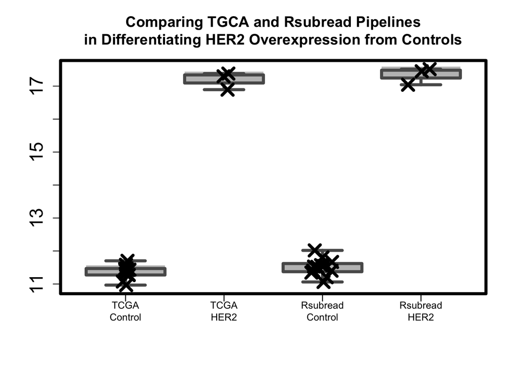

```r
#########After removing the outlier GFP and HER2 samples

par(mfrow = c(1, 1),lwd=4)
names=c('TCGA\nGFP','TCGA\nHER2','Rsubread\nGFP', 'Rsubread\nHER2')
rsem_her2<-data.frame(t(rsem_her2_expected_counts["ERBB2",c(1:12,13,15,17)]))
rsub_her2<-data.frame(t(feature["ERBB2",c(1:12,13,15,17)]))
x = c(rep(1, 12), rep(2, 3),rep(3, 12), rep(4, 3))

boxplot(log2(rsem_her2$ERBB2[1:12]+1),log2(rsem_her2$ERBB2[13:15]+1),log2(rsub_her2$ERBB2[1:12]+1),log2(rsub_her2$ERBB2[13:15]+1),ylab="",range=0,cex.axis=1.5, cex.lab=1.5,outpch=NA,col='grey75',medcol="grey75",lwd=4,main=paste('Comparing TGCA and Rsubread Pipelines','\n', 'in Differentiating HER2 Overexpression from Controls',sep=''),border = "grey35")

points(jitter(rep(1,12),factor=2),log2(rsem_her2$ERBB2[1:12]+1),pch=4,cex=2,cex.lab=1.5,col="black")
points(jitter(rep(2,3),factor=2),log2(rsem_her2$ERBB2[13:15]+1),pch=4,cex=2,cex.lab=1.5,col='black')
points(jitter(rep(3,12),factor=2),log2(rsub_her2$ERBB2[1:12]+1),pch=4,cex=2,cex.lab=1.5,col='black')
points(jitter(rep(4,3),factor=2),log2(rsub_her2$ERBB2[13:15]+1),pch=4,cex=2,cex.lab=1.5,col='black')
axis(1, at=1:4, tick=T, labels=c("TCGA\nControl", "TCGA\nHER2","Rsubread\nControl", "Rsubread\nHER2"), cex.axis=0.8)
```

```r
##using data processed by RSEM detected difference in her2 gene count in HER2 overexpressed versus GFP overexpressed samples
##t = -12.1833, df = 4.157, p-value = 0.0002081 but was worse than Rsubread
t.test(log2(rsem_her2$ERBB2[1:11]+1),log2(rsem_her2$ERBB2[12:14]+1))
```

```
##
##  Welch Two Sample t-test
##
## data:  log2(rsem_her2$ERBB2[1:11] + 1) and log2(rsem_her2$ERBB2[12:14] + 1)
## t = -1.7938, df = 2.002, p-value = 0.2146
## alternative hypothesis: true difference in means is not equal to 0
## 95 percent confidence interval:
##  -12.944351   5.321063
## sample estimates:
## mean of x mean of y
##  11.40316  15.21480
```

```r
##using not normalized data processed by Rsubread was much better at detecting difference in her2 gene count in HER2 overexpressed versus GFP overexpressed samples
##t = -46.6747, df = 8.35, p-value = 2.152e-11
t.test(log2(rsub_her2$ERBB2[1:11]+1),log2(rsub_her2$ERBB2[12:14]+1))
```

```
##
##  Welch Two Sample t-test
##
## data:  log2(rsub_her2$ERBB2[1:11] + 1) and log2(rsub_her2$ERBB2[12:14] + 1)
## t = -1.7725, df = 2.004, p-value = 0.2181
## alternative hypothesis: true difference in means is not equal to 0
## 95 percent confidence interval:
##  -12.991926   5.400484
## sample estimates:
## mean of x mean of y
##  11.54623  15.34195
```

```r
###########here we are computing standardized mean difference using the exprected gene counts from TCGA pipeline and gene counts from Rsubread algorithm ############

####Hedge's standardized mean/effect size using TCGA pipeline
standardized_mean(mean(log2(rsem_her2$ERBB2[13:15]+1)),sd(log2(rsem_her2$ERBB2[13:15]+1)),3,mean(log2(rsem_her2$ERBB2[1:12]+1)),sd(log2(rsem_her2$ERBB2[1:12]+1)),12)
```

```
## [1] 27.2547
```

```r
standardized_mean(m.1=mean((log2(rsem_her2$ERBB2[13:15]+1))),sd.1=sd((log2(rsem_her2$ERBB2[13:15]+1))),n.1=3,m.2=mean((log2(rsem_her2$ERBB2[1:12]+1))),sd.2=sd((log2(rsem_her2$ERBB2[1:12]+1))),n.2 = 12)
```

```
## [1] 27.2547
```

```r
####Hedge's standardized mean/effect size using Rsubread pipeline
standardized_mean(m.1=mean((log2(rsub_her2$ERBB2[13:15]+1))),sd.1=sd((log2(rsub_her2$ERBB2[13:15]+1))),n.1=3,m.2=mean((log2(rsub_her2$ERBB2[1:12]+1))),sd.2=sd((log2(rsub_her2$ERBB2[1:12]+1))),n.2 = 12)
```

```
## [1] 22.75737
```

### “Normalized gene counts” level analysis

We compared normalized gene counts results using GFP control protein and ERBB2 protein overexpressed human mammary epithelial cell samples. Log based 2 gene expression of the TCGA Level 3 data, Rsubread processed FPKM and TPM data are used for this analysis.

First, we computed the consistency of the gene expression across common genes after normalization. Second, empiric cumulative distribution for all samples from two pipelines. Second, we compared the total mapped read per HMEC samples from TCGA pipeline & Rsubread pipeline. Third, we compared HER2(ERBB2) gene expressions between control and HER2-overexpressed samples.

```
## [1] "Coefficient of variation in TCGA Level 3 data across 19585 genes in the control samples: 0.153558981835486"
```

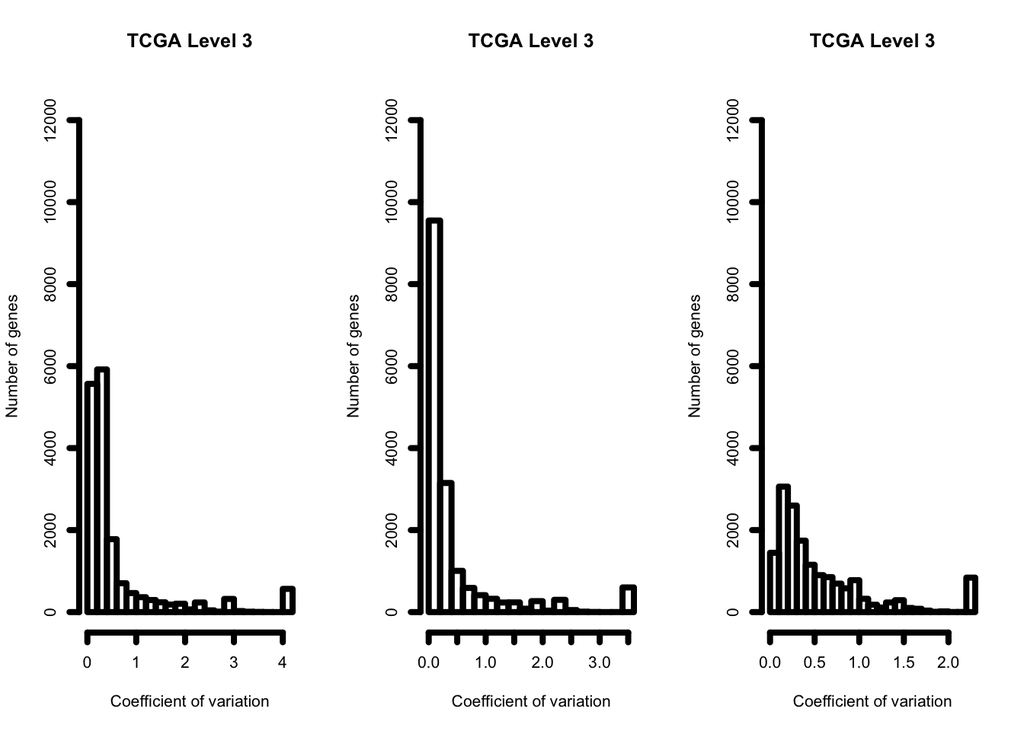

```
## [1] "Coefficient of variation in TCGA Level 3 data across 19585 genes in the HER2-overexpressed samples: 0.347545997340965"
```

```
## [1] "Coefficient of variation in Rsubread FPKM normalized data across 19585 genes in the control samples:0.131497785015414"
```

```
## [1] "Coefficient of variation in Rsubread FPKM normalized data across 19585 genes in the HER2-overexpressed samples:0.0962553873622692"
```

```
## [1] "Coefficient of variation in Rsubread TPM normalized data across 19585 genes in the control samples:0.131497785015414"
```

```
## [1] "Coefficient of variation in Rsubread TPM normalized data across 19585 genes in the HER2-overexpressed samples:0.0962553873622692"
```

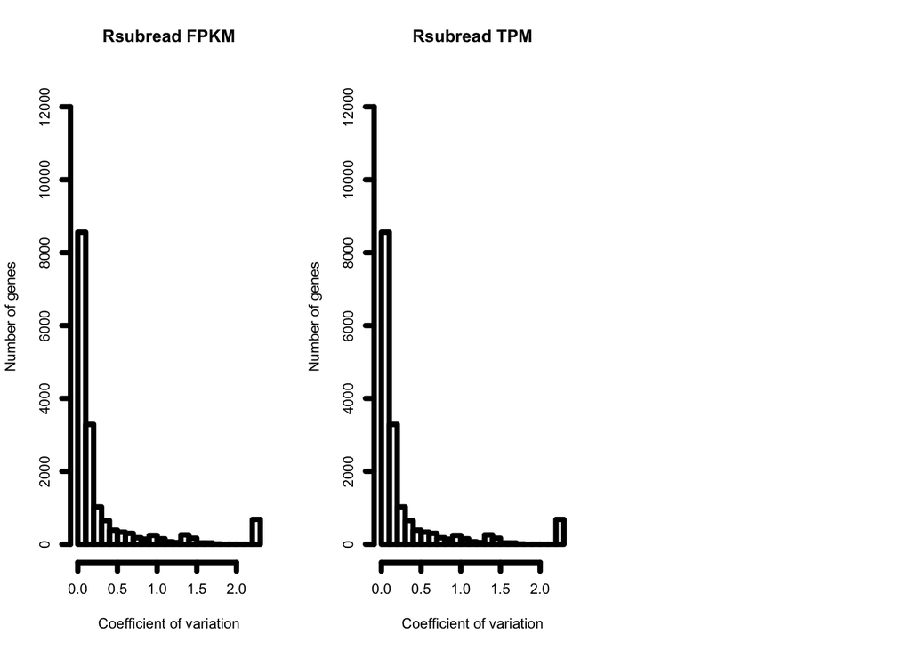

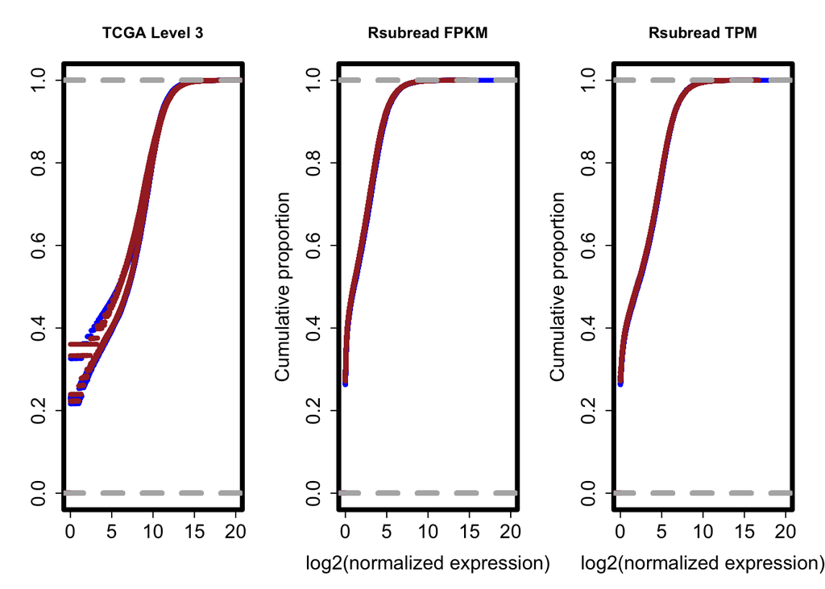

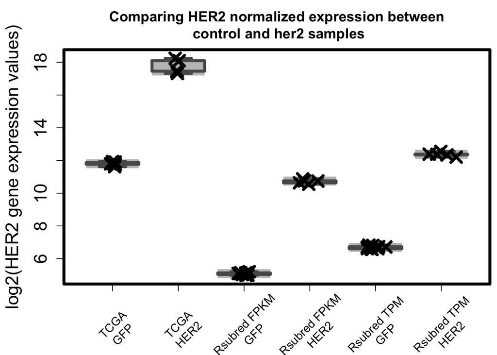

```
##
##  Welch Two Sample t-test
##
## data:  log2(tcga_her2_normalized$ERBB2[1:12] + 1) and log2(tcga_her2_normalized$ERBB2[13:17] + 1)
## t = -31.2088, df = 4.145, p-value = 4.463e-06
## alternative hypothesis: true difference in means is not equal to 0
## 95 percent confidence interval:
##  -6.430039 -5.392647
## sample estimates:
## mean of x mean of y
##  11.80428  17.71562
```

```
##
##  Welch Two Sample t-test
##
## data:  rsub_fpkmlog_her2$ERBB2[1:12] and rsub_fpkmlog_her2$ERBB2[13:17]
## t = -96.8806, df = 4.939, p-value = 2.73e-09
## alternative hypothesis: true difference in means is not equal to 0
## 95 percent confidence interval:
##  -5.775412 -5.475761
## sample estimates:
## mean of x mean of y
##  5.085548 10.711135
```

```
##
##  Welch Two Sample t-test
##
## data:  rsub_tpmlog_her2$ERBB2[1:12] and rsub_tpmlog_her2$ERBB2[13:17]
## t = -93.9768, df = 5.501, p-value = 4.949e-10
## alternative hypothesis: true difference in means is not equal to 0
## 95 percent confidence interval:
##  -5.837449 -5.534713
## sample estimates:
## mean of x mean of y
##  6.687464 12.373545
```

```
## [1] 25.77642
```

```
## [1] 66.91743
```

```
## [1] 67.15595
```

```
## [1] 64.77116
```

```
## [1] 77.93966
```

```
## [1] 81.85702
```

Coefficient of variation in ERBB2 gene in HER2 overexpressed samples using TCGA pipeline is: 0.3000375 using Rsubread FPKM pipeline is: 0.0852205and using Rsubread TPM pipeline is: 0.0871093

### Assessing the number of zeroes per sample

Now checking the total number of zeros per samples in the common samples accross PanCan12 and our datasets

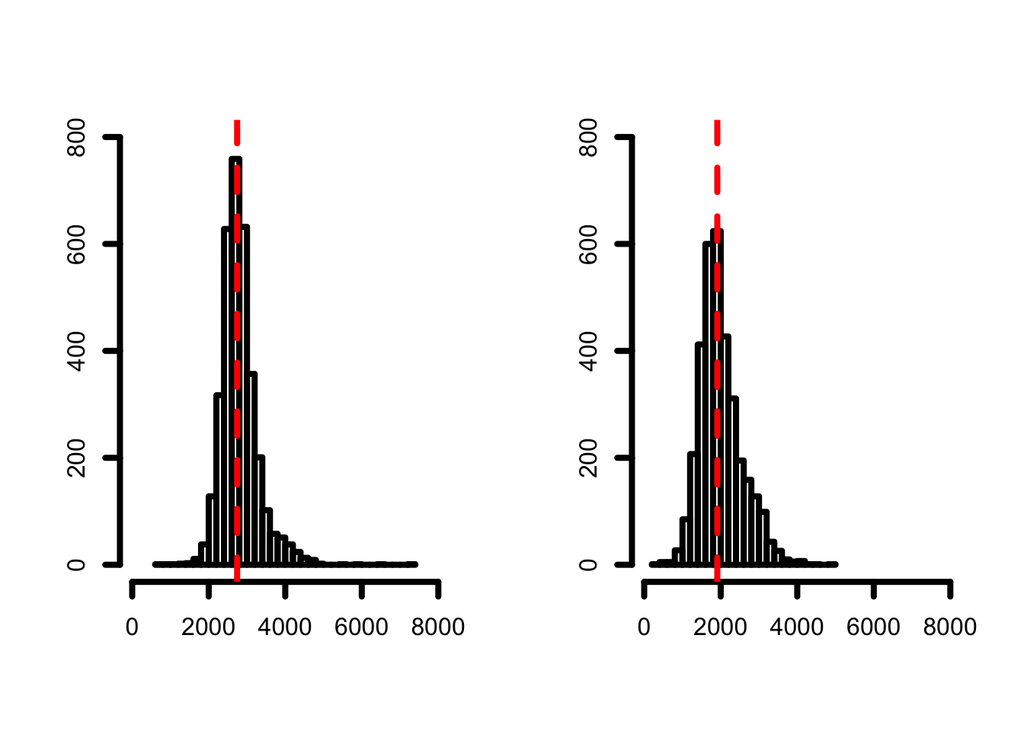

```
##
##  Welch Two Sample t-test
##
## data:  all_zeros$PANCAN12 and all_zeros$TPM
## t = 65.1099, df = 6625.832, p-value < 2.2e-16
## alternative hypothesis: true difference in means is not equal to 0
## 95 percent confidence interval:
##  781.7462 830.2810
## sample estimates:
## mean of x mean of y
##  2805.936  1999.922
```

### Comparing Her2 predictions

We predicted HER2 pathway using our overexpressed samples in human mammary epithelial cells(HMECs) in TCGA breast cancer samples. We used TCGA pipeline processed HMEC datasets on TCGA pipeline processed TCGA BRCA samples and Rsubread pipelined processed HMEC datasets on Rsubread processed TCGA BRCA samples. We only compared BRCA samples that are common and we have her2 status confirmed by immunohistochemistry. Our goal here is to compare how well these two pipeline and normalization method differenciate HER2 pathway activity predictions where we know the status of HER2 overexpression.

We removed all the genes that had zero expression accross all HMEC samples and TCGA samples. Then, we used quantile normalization method to adjust for batch variation between our HMEC training samples and TCGA BRCA samples. We used binary regression model developed by West et al to generate HER2 signatures using top 200 genes. The signature generated from each pipeline processed data was used to predict on TCGA BRCA RNA-Seq sample processed by the same pipeline. Both FPKM-log2 and TPM-log2 normalized Rsubread processed predictions were compiled to one file and TCGA upper-quantile log-2 normalized pipeline procssed predictions were extracted to another file for analysis.

We compared the boxplots for HER2 pathway activation status predictions between HER2(+) and HER2(-) BRCA samples.

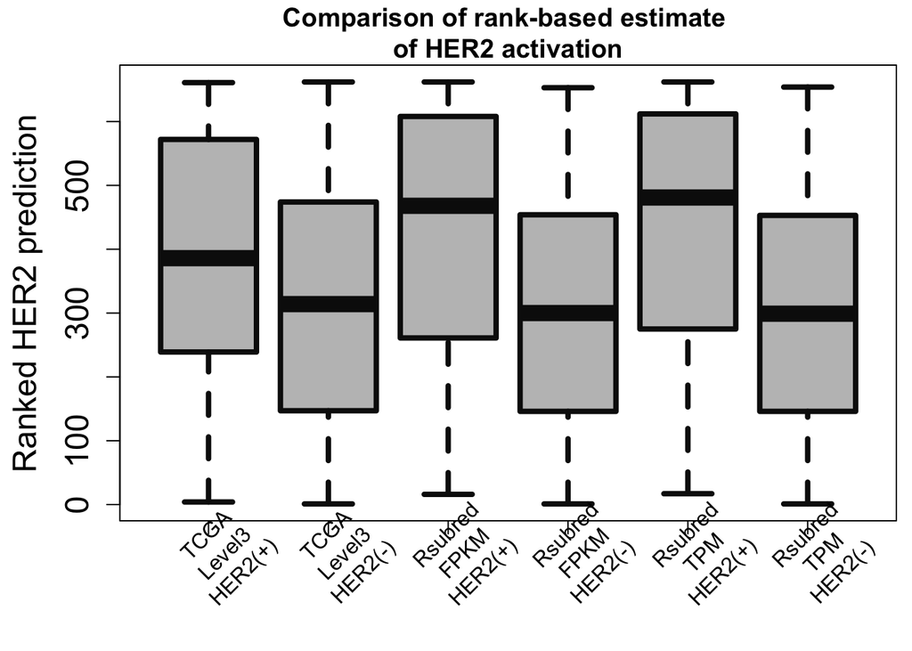

```
## [1] "Coefficient of variation in TCGA pipeline processed HER2 predictions in HER2(-) BRCA samples 0.718551791082337"
```

```
## [1] "Coefficient of variation in TCGA pipeline processed HER2 predictions in HER2(+) BRCA samples 0.622878846823398"
```

```
## [1] "Coefficient of variation in Rsubread FPKM processed HER2 predictions in HER2(-) BRCA samples  0.207474351412"
```

```
## [1] "Coefficient of variation in Rsubread FPKM processed HER2 predictions in HER2(+) BRCA samples  0.136350713609132"
```

```
## [1] "Coefficient of variation in Rsubread TPM  processed HER2 predictions in HER2(-) BRCA samples  0.298841977949989"
```

```
## [1] "Coefficient of variation in Rsubread TPM processed HER2 predictions in HER2(+) BRCA samples  0.199164991039233"
```

```
## [1] "Standardized mean difference in prediction between HER2 (+) and HER2 (-) samples for TCGA Level 3 data : 0.437899643965005"
```

```
## [1] "Standardized mean difference in predicrion between HER2 (+) and HER2 (-) samples for Rsubread FPKM data : 0.517617545336065"
```

```
## [1] "Standardized mean difference in predicrion between HER2 (+) and HER2 (-) samples for FPKM TPM data : 0.590146326462997"
```

```
##
##  Welch Two Sample t-test
##
## data:  ihc_pos_t$Rsem_log_q_200_f and ihc_neg_t$Rsem_log_q_200_f
## t = 4.3599, df = 217.213, p-value = 2.009e-05
## alternative hypothesis: true difference in means is not equal to 0
## 95 percent confidence interval:
##  0.05731397 0.15188620
## sample estimates:
## mean of x mean of y
## 0.4256819 0.3210818
```

```
##
##  Welch Two Sample t-test
##
## data:  ihc_pos_t$FPKM_log_q_200_f and ihc_neg_t$FPKM_log_q_200_f
## t = 6.6169, df = 328.368, p-value = 1.493e-10
## alternative hypothesis: true difference in means is not equal to 0
## 95 percent confidence interval:
##  0.05522649 0.10195772
## sample estimates:
## mean of x mean of y
## 0.8529022 0.7743100
```

```
##
##  Welch Two Sample t-test
##
## data:  ihc_pos_t$TPM_log_q_200_f and ihc_neg_t$TPM_log_q_200_f
## t = 7.2634, df = 303.609, p-value = 3.197e-12
## alternative hypothesis: true difference in means is not equal to 0
## 95 percent confidence interval:
##  0.08497343 0.14812503
## sample estimates:
## mean of x mean of y
## 0.8086601 0.6921109
```

If the outlier training samples are removed from both samples..

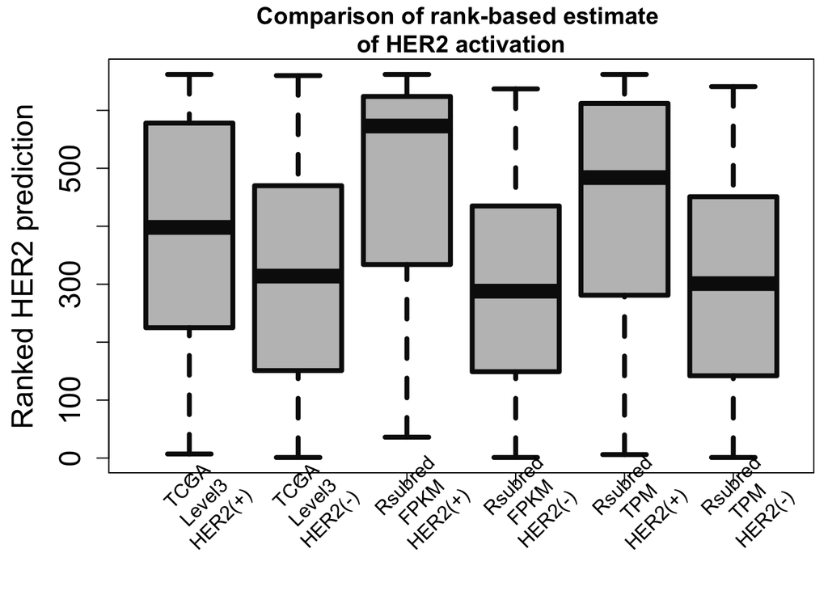

```r
##############boxplot of ranked estimated HER2 pathway activity
##in TCGA BRCA samples####
setwd("~/Dropbox/TCGA_RNASeq_Clinical/Analysis_datasets/")
rsub_preds<-read.table("Rsub_5_01.txt", sep='\t', header=1, row.names=1)
tcga_preds<-read.table("Rsem_5_01.txt", sep='\t', header=1, row.names=1)

all_preds<-merge_drop(rsub_preds,tcga_preds,by=0)
brca_clinical<-subset(clinicals,clinicals[,'tumor_tissue_site']=='Breast',select=c("bcr_patient_barcode","her2_status_by_ihc"))
common_all<-merge_drop(all_preds,brca_clinical,by=0)
all_preds_pos_neg<-subset(common_all,common_all$her2_status_by_ihc=="Negative"|common_all$her2_status_by_ihc=="Positive")
all_ranked<-apply(all_preds_pos_neg[,1:3],2,rank)
all<-cbind(all_ranked,all_preds_pos_neg[,4:5])
ihc_neg<-subset(all,all$her2_status_by_ihc=="Negative")
ihc_pos<-subset(all,all$her2_status_by_ihc=="Positive")


par(mfrow = c(1, 1))
par(mar=c(5, 4.6, 2.5, 0.6)) # figure margins
boxplot(ihc_pos$RSEM_preds,ihc_neg$RSEM_preds,ihc_pos$RSUB_FPKM,ihc_neg$RSUB_FPKM,ihc_pos$RSUB_TPM,ihc_neg$RSUB_TPM,cex.axis=1.5, cex.lab=1.5,outpch=NA,range=0,cex.axis=1, cex.lab=0.7,outpch=NA,col='grey75',medcol="grey5",lwd=4,border = "grey5", main="Comparison of rank-based estimate \nof HER2 activation",ylab="Ranked HER2 prediction")
names=c("TCGA\nLevel3\nHER2(+)","TCGA\nLevel3\nHER2(-)","Rsubred\nFPKM\nHER2(+)", "Rsubred\nFPKM\nHER2(-)","Rsubred\nTPM\nHER2(+)", "Rsubred\nTPM\nHER2(-)")
text(seq(1,6,by=1),par("usr")[3] - 4.5, labels = names, srt = 45, pos = 1, xpd = TRUE)
```

```r
ihc_neg_t<-subset(common_all,common_all$her2_status_by_ihc=="Negative")
ihc_pos_t<-subset(common_all,common_all$her2_status_by_ihc=="Positive")

##coefficient of variation in TCGA pipeline processed HER2 predictions
print(paste("Coefficient of variation in TCGA pipeline processed HER2 predictions in HER2(-) BRCA samples",sd(ihc_neg_t$RSEM_preds)/mean(ihc_neg_t$RSEM_preds),sep=' '))
```

```
## [1] "Coefficient of variation in TCGA pipeline processed HER2 predictions in HER2(-) BRCA samples 0.231926367662448"
```

```r
print(paste("Coefficient of variation in TCGA pipeline processed HER2 predictions in HER2(+) BRCA samples",sd(ihc_pos_t$RSEM_preds)/mean(ihc_pos_t$RSEM_preds),sep=' '))
```

```
## [1] "Coefficient of variation in TCGA pipeline processed HER2 predictions in HER2(+) BRCA samples 0.153902974075226"
```

```r
##coefficient of variation in Rsubread FPKM pipeline processed HER2 predictions
print(paste("Coefficient of variation in Rsubread FPKM processed HER2 predictions in HER2(-) BRCA samples",sd(ihc_neg_t$RSUB_FPKM)/mean(ihc_neg_t$RSUB_FPKM),sep="  "))
```

```
## [1] "Coefficient of variation in Rsubread FPKM processed HER2 predictions in HER2(-) BRCA samples  0.189096581056837"
```

```r
print(paste("Coefficient of variation in Rsubread FPKM processed HER2 predictions in HER2(+) BRCA samples",sd(ihc_pos_t$RSUB_FPKM)/mean(ihc_pos_t$RSUB_TPM),sep="  "))
```

```
## [1] "Coefficient of variation in Rsubread FPKM processed HER2 predictions in HER2(+) BRCA samples  0.225844880146422"
```

```r
##coefficient of variation in Rsubread TPM pipeline processed HER2 predictions
print(paste("Coefficient of variation in Rsubread TPM  processed HER2 predictions in HER2(-) BRCA samples",sd(ihc_neg_t$RSUB_TPM)/mean(ihc_neg_t$RSUB_TPM),sep="  "))
```

```
## [1] "Coefficient of variation in Rsubread TPM  processed HER2 predictions in HER2(-) BRCA samples  0.198754706917192"
```

```r
print(paste("Coefficient of variation in Rsubread TPM processed HER2 predictions in HER2(+) BRCA samples",sd(ihc_pos_t$RSUB_TPM)/mean(ihc_pos_t$RSUB_TPM),sep="  "))
```

```
## [1] "Coefficient of variation in Rsubread TPM processed HER2 predictions in HER2(+) BRCA samples  0.129042743170408"
```

```r
##Calculating standardized mean differences between the HER2(+) and HER2(-) groups
print(paste("Standardized mean difference in prediction between HER2 (+) and HER2 (-) samples for TCGA Level 3 data :",standardized_mean(m.1=mean(ihc_pos_t$RSEM_preds),sd.1=sd(ihc_pos_t$RSEM_preds),n.1=length(ihc_pos_t$RSEM_preds),m.2=mean(ihc_neg_t$RSEM_preds),sd.2=sd(ihc_neg_t$RSEM_preds),n.2=length(ihc_neg_t$RSEM_preds)),sep=' '))
```

```
## [1] "Standardized mean difference in prediction between HER2 (+) and HER2 (-) samples for TCGA Level 3 data : 0.396175972187927"
```

```r
print(paste("Standardized mean difference in prediction between HER2 (+) and HER2 (-) samples for Rsubread FPKM data :",standardized_mean(m.1=mean(ihc_pos_t$RSUB_FPKM),sd.1=sd(ihc_pos_t$RSUB_FPKM),n.1=length(ihc_pos_t$RSUB_FPKM),m.2=mean(ihc_neg_t$RSUB_FPKM),sd.2=sd(ihc_neg_t$RSUB_FPKM),n.2=length(ihc_neg_t$RSUB_FPKM)),sep=' '))
```

```
## [1] "Standardized mean difference in prediction between HER2 (+) and HER2 (-) samples for Rsubread FPKM data : 1.43060003804799"
```

```r
print(paste("Standardized mean difference in prediction between HER2 (+) and HER2 (-) samples for TPM data :",standardized_mean(m.1=mean(ihc_pos_t$RSUB_TPM),sd.1=sd(ihc_pos_t$RSUB_TPM),n.1=length(ihc_pos_t$RSUB_TPM),m.2=mean(ihc_neg_t$RSUB_TPM),sd.2=sd(ihc_neg_t$RSUB_TPM),n.2=length(ihc_neg_t$RSUB_TPM)),sep=' '))
```

```
## [1] "Standardized mean difference in prediction between HER2 (+) and HER2 (-) samples for TPM data : 0.547348277056792"
```

```r
## t-tests comparing HER(+) and HER(-) prediction
t.test(ihc_pos_t$RSEM_preds,ihc_neg_t$RSEM_preds)# For TCGA Level 3: p-value = 2.009e-05
```

```
##
##  Welch Two Sample t-test
##
## data:  ihc_pos_t$RSEM_preds and ihc_neg_t$RSEM_preds
## t = 5.0742, df = 329.729, p-value = 6.512e-07
## alternative hypothesis: true difference in means is not equal to 0
## 95 percent confidence interval:
##  0.03811287 0.08637478
## sample estimates:
## mean of x mean of y
## 0.7793464 0.7171026
```

```r
t.test(ihc_pos_t$RSUB_FPKM,ihc_neg_t$RSUB_FPKM)#For Rsubread FPKM: p-value = 1.493e-10
```

```
##
##  Welch Two Sample t-test
##
## data:  ihc_pos_t$RSUB_FPKM and ihc_neg_t$RSUB_FPKM
## t = 10.1904, df = 163.022, p-value < 2.2e-16
## alternative hypothesis: true difference in means is not equal to 0
## 95 percent confidence interval:
##  0.1264417 0.1872210
## sample estimates:
## mean of x mean of y
## 0.5587175 0.4018861
```

```r
t.test(ihc_pos_t$RSUB_TPM,ihc_neg_t$RSUB_TPM)#For Rsubread TPM:p-value = 3.197e-12
```

```
##
##  Welch Two Sample t-test
##
## data:  ihc_pos_t$RSUB_TPM and ihc_neg_t$RSUB_TPM
## t = 7.0367, df = 332.411, p-value = 1.131e-11
## alternative hypothesis: true difference in means is not equal to 0
## 95 percent confidence interval:
##  0.05445660 0.09671804
## sample estimates:
## mean of x mean of y
## 0.8118021 0.7362148
```

Both pipelines were significant in differentiating between HER2(+) and HER(-) samples using HER2 signature. However, Rsubread has the bigger standardized mean difference between the two subtypes.

Finally, we are assessing the classification predictions using 10-fold cross validation and using TCGA Level 3 and Rsubread TPM normalized lung adenocarcinoma and lung squamous carcinoma samples. Rsubread processed data had better accuracy in predicting class than TCGA Level 3 data.

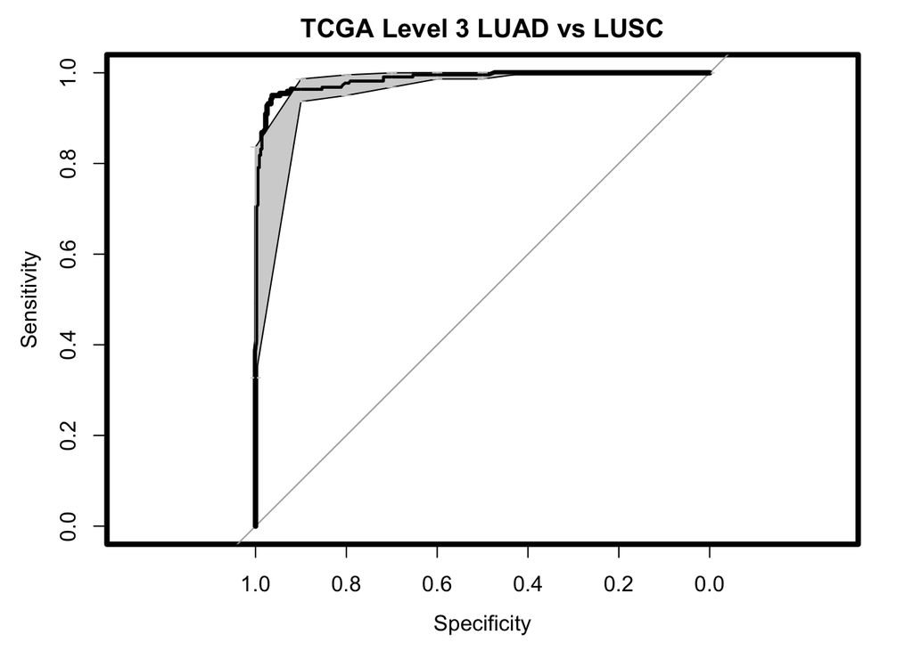

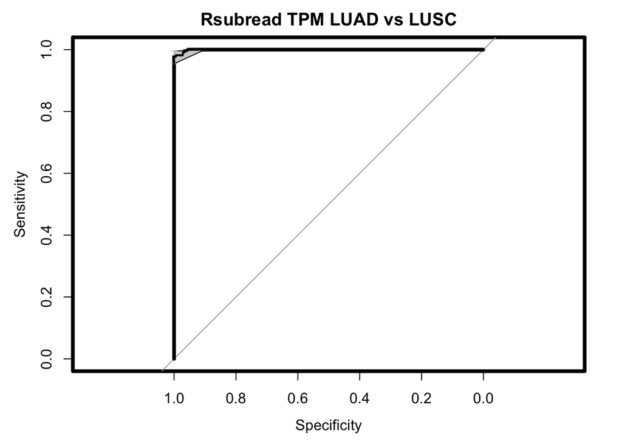

This analysis was run on Tue May 26 02:15:47 2015